# NLB: Podatkovni Znanstvenik - Naloge

Avtor

Ana Pangrc

Objavljeno

18. april 2026

# 1. Naloga: Časovne vrste

## 1.1 Vizualizacija in interpretacija podatkov

**Koda**

```python
# Uvoz knjižnic
import pandas as pd
import numpy as np
import matplotlib.pyplot as plt
import seaborn as sns

# Nastavitve za lepše grafe
plt.rcParams['figure.figsize'] = (12, 5)
plt.rcParams['font.size'] = 12
sns.set_theme(style="whitegrid")

# Uvoz podatkov
bdp = pd.read_csv('bdp.csv', sep=None, engine='python')
brezposelnost = pd.read_csv('brezposelnost.csv', sep=None, engine='python')
euribor = pd.read_csv('euribor.csv', sep=None, engine='python')
nepremicnine = pd.read_csv('nepremicnine.csv', sep=None, engine='python')

# Enotno poimenovanje stolpcev
bdp.columns = ['Cetrtletje', 'BDP']
brezposelnost.columns = ['Cetrtletje', 'Brezposelnost']
euribor.columns = ['Cetrtletje', 'Euribor']
nepremicnine.columns = ['Cetrtletje', 'Nepremicnine']

# Združitev vseh tabel v eno
df = bdp.merge(brezposelnost, on='Cetrtletje')
df = df.merge(euribor, on='Cetrtletje')
df = df.merge(nepremicnine, on='Cetrtletje')
df['Indeks'] = range(len(df))

print("Knjižnice uvožene")
```

```
Knjižnice uvožene
```

**Koda**

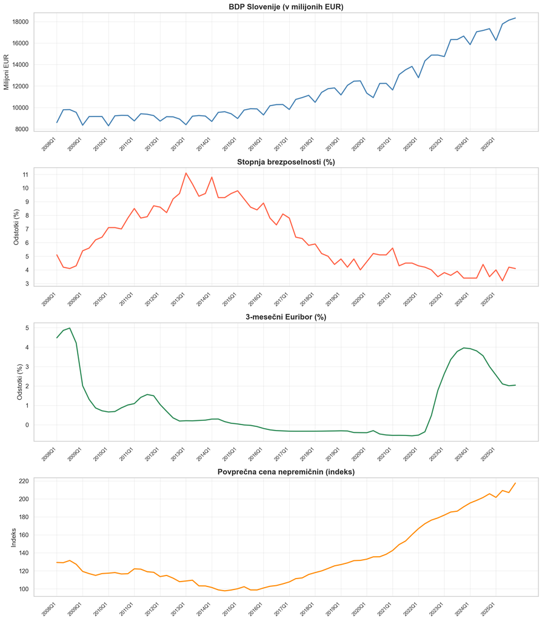

```
Grafi shranjeni
```

```python
# Izris grafov za vse 4 spremenljivke
fig, axes = plt.subplots(4, 1, figsize=(14, 16))

# Graf 1: BDP
axes[0].plot(df['Indeks'], df['BDP'], color='steelblue', linewidth=2)
axes[0].set_title('BDP Slovenije (v milijonih EUR)', fontsize=14, fontweight='bold')
axes[0].set_ylabel('Milijoni EUR')

# Graf 2: Brezposelnost
axes[1].plot(df['Indeks'], df['Brezposelnost'], color='tomato', linewidth=2)
axes[1].set_title('Stopnja brezposelnosti (%)', fontsize=14, fontweight='bold')
axes[1].set_ylabel('Odstotki (%)')

# Graf 3: Euribor
axes[2].plot(df['Indeks'], df['Euribor'], color='seagreen', linewidth=2)
axes[2].set_title('3-mesečni Euribor (%)', fontsize=14, fontweight='bold')
axes[2].set_ylabel('Odstotki (%)')

# Graf 4: Nepremičnine
axes[3].plot(df['Indeks'], df['Nepremicnine'], color='darkorange', linewidth=2)
axes[3].set_title('Povprečna cena nepremičnin (indeks)', fontsize=14, fontweight='bold')
axes[3].set_ylabel('Indeks')

# Oznake na x-osi (vsako 4. četrtletje = vsako leto)
leta = df['Cetrtletje'][::4].values
pozicije = df['Indeks'][::4].values
for ax in axes:
    ax.set_xticks(pozicije)
    ax.set_xticklabels(leta, rotation=45, ha='right', fontsize=9)
    ax.grid(True, alpha=0.3)

plt.tight_layout()
plt.savefig('grafi_casovne_vrste.png', dpi=150, bbox_inches='tight')
plt.show()
print("Grafi shranjeni")
```

### Interpretacija grafov

**BDP Slovenije** kaže dolgoročni trend rasti z dvema opaznejšima padcema: finančna kriza 2008-2009 in COVID-19 2020. Vidna je tudi sezonskost - BDP je višji v poletnih četrtletjih. Po vsaki krizi sledi okrevanje in nadaljevanje rasti.

**Brezposelnost** je obratno sorazmerna z BDP. Vrh ~11% je bil dosežen v 2013 kot zakasnjen učinek finančne krize, nato sledi trend padanja do danes (izjema: kratki skok ob COVID-19).

**Euribor** je doživel dramatičen padec po 2008, sledilo je zgodovinsko dolgo obdobje negativnih obrestnih mer (2015-2022), nato hiter dvig zaradi inflacije in sedaj ponoven padec.

**Cene nepremičnin** so padle po 2008 krizi, od 2015 pa beležimo neprestano rast - cene so se od takrat več kot podvojile. Ni jasnega sezonskega vzorca.

**Koda**

```
Korelacijska matrika:
                BDP  Brezposelnost  Euribor  Nepremicnine
BDP            1.00          -0.75     0.36          0.95
Brezposelnost -0.75           1.00    -0.41         -0.77
Euribor        0.36          -0.41     1.00          0.52
Nepremicnine   0.95          -0.77     0.52          1.00
```

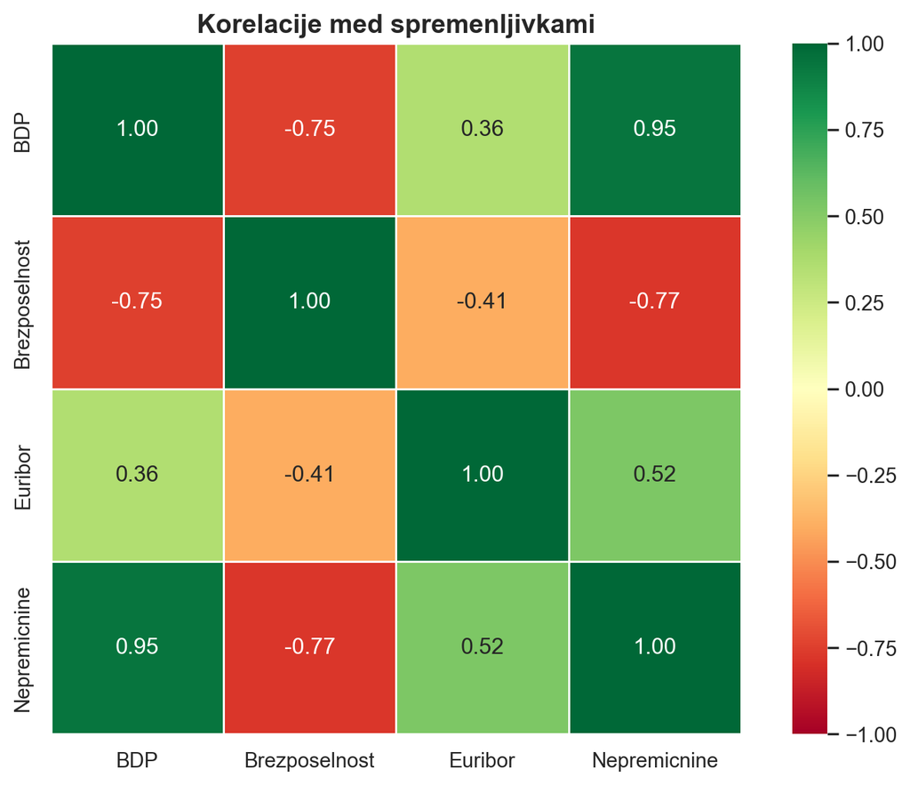

```
Korelacijska matrika shranjena
```

```python
# Izračun korelacije med vsemi spremenljivkami
korelacije = df[['BDP', 'Brezposelnost', 'Euribor', 'Nepremicnine']].corr()

print("Korelacijska matrika:")
print(korelacije.round(2))

# Heatmap (barvna tabela korelacij)
plt.figure(figsize=(8, 6))
sns.heatmap(korelacije,
            annot=True,
            fmt='.2f',
            cmap='RdYlGn',
            vmin=-1, vmax=1,
            square=True,
            linewidths=0.5)
plt.title('Korelacije med spremenljivkami', fontsize=14, fontweight='bold')
plt.tight_layout()
plt.savefig('korelacije.png', dpi=150, bbox_inches='tight')
plt.show()
print("Korelacijska matrika shranjena")
```

### Odnosi med spremenljivkami

- **BDP in NEPREMIČNINE (0.95):** Zelo močna pozitivna korelacija - gospodarska rast spodbuja povpraševanje po nepremičninah. Višji dohodki pomenijo več nakupov nepremičnin. Najpomembnejša povezava v podatkih.
- **BDP in BREZPOSELNOST (-0.75):** Močna negativna korelacija - klasična ekonomska zakonitost (Okunov zakon). Gospodarska rast ustvarja delovna mesta.
- **NEPREMIČNINE in BREZPOSELNOST (-0.77):** Visoka brezposelnost zmanjša povpraševanje po nepremičninah. Brezposelni ne morejo pridobiti hipotekarnih kreditov.
- **EURIBOR in NEPREMIČNINE (0.52):** Presenetljivo pozitivna - pričakovali bi negativno. Razlog: oba visoka v 2008, oba nizka 2015-2021, oba spet rasla po 2022. Dolgoročno višji Euribor = dražji krediti = manj povpraševanja po nepremičninah.

**Opomba:** Korelacija ne pomeni vzročnosti! Spremenljivke so lahko povezane zaradi skupnih zunanjih dejavnikov (npr. gospodarski cikel).

## 1.2 Napoved cen nepremičnin - ARIMAX model

**Koda**

```python
odgovori_1_2 = """
ODGOVORI NA VPRAŠANJA - 1.2 ARIMAX MODEL
==========================================

VPRAŠANJE 1: Kakšne časovne vrste so primerne za ARIMAX?
----------------------------------------------------------
ARIMAX model zahteva STACIONARNE časovne vrste.
Stacionarna časovna vrsta ima:
- Konstantno povprečje skozi čas (brez trenda)
- Konstantno varianco (brez vse večjih nihanj)
- Ni sezonskosti

Naši podatki (BDP, nepremičnine) NISO stacionarni - imajo trend rasti.
Zato jih moramo pred modeliranjem 'stacionarizirati' z diferenciranjem
(od vsake vrednosti odštejemo prejšnjo vrednost).

TESTI PRED MODELIRANJEM:
- ADF test (Augmented Dickey-Fuller): preverimo ali je vrsta stacionarna
- KPSS test: dodatna potrditev stacionarnosti
- ACF/PACF grafi: pomagajo določiti parametre modela (p, q)
- Test sezonskosti: preverimo ali obstajajo sezonski vzorci

TESTI PO MODELIRANJU:
- Ljung-Box test: preverimo ali so ostanki (napake modela) naključni
- Shapiro-Wilk test: preverimo ali so ostanki normalno porazdeljeni
- Test heteroskedastičnosti: preverimo ali je varianca ostankov konstantna

VPRAŠANJE 2: Kaj mora veljati za eksogene spremenljivke?
---------------------------------------------------------
Eksogene spremenljivke morajo biti:
1. Stacionarne (ali jih stacionariziramo)
2. Dostopne v trenutku napovedi - problem: BDP za naslednje četrtletje
   še ne poznamo ko delamo napoved! Rešitev: uporabimo napoved BDP
   ali zamaknjene vrednosti (vrednosti iz prejšnjega četrtletja)
3. Neodvisne med seboj (ni multikolinearnosti)
4. Vzročno povezane z odvisno spremenljivko (ne samo korelirane)

VPRAŠANJE 3: Katera eksogena spremenljivka bi najbolj vplivala?
---------------------------------------------------------------
Po našem mnenju: BDP
Razlogi:
- Najvišja korelacija z nepremičninami (0.95)
- Ekonomsko logična povezava (gospodarska rast → višje cene)
- BDP zajema splošno gospodarsko stanje

Na drugem mestu: Brezposelnost (-0.77)
- Visoka brezposelnost zmanjša povpraševanje po nepremičninah
- Vpliva na sposobnost pridobitve hipotekarnega kredita

Euribor (0.52) je sicer pomemben, vendar njegova korelacija z
nepremičninami ni tako enoznačna kot pri BDP.

VPRAŠANJE 4: Kako oceniti napovedno moč modela?
------------------------------------------------
- Podatke razdelimo na učno množico (npr. 2008-2022) in testno (2023-2025)
- Model naučimo na učni množici, napovedi naredimo za testno
- Merimo napako napovedi z:
  * MAE (povprečna absolutna napaka)
  * RMSE (koren povprečne kvadratne napake)
  * MAPE (povprečna odstotna napaka)
- Pričakovana napoved: zmerna natančnost, ker cene nepremičnin
  so odvisne tudi od dejavnikov ki jih nimamo v modelu

VPRAŠANJE 5: Kako določiti parametre modela?
--------------------------------------------
Parametri ARIMAX modela so (p, d, q)(P, D, Q):
- p: število avtoregesivnih členov → določimo z PACF grafom
- d: stopnja diferenciranja → določimo z ADF testom
- q: število členov drsečega povprečja → določimo z ACF grafom
- Sezonski parametri (P,D,Q) → določimo z analizo sezonskosti

Praktično: uporabimo funkcijo auto_arima() ki samodejno poišče
najboljše parametre z minimizacijo kriterija AIC/BIC.

VPRAŠANJE 6: Kako bi napoved še izboljšali?
-------------------------------------------
Možne izboljšave:
1. Dodatni podatki:
   - Število izdanih gradbenih dovoljenj (ponudba nepremičnin)
   - Populacijski trendi in migracije
   - Povprečne plače (kupna moč)
   - Število odobrenih hipotek

2. Alternativni modeli:
   - VAR (Vector Autoregression): modelira vse spremenljivke skupaj
   - LSTM nevronska mreža: boljša pri kompleksnih nelinearnih vzorcih
   - XGBoost z zamaknjenimi spremenljivkami: dobro za tabelarične podatke

3. Tehnične izboljšave:
   - Daljše časovno obdobje (več podatkov = boljši model)
   - Mesečni namesto četrtletnih podatkov (več podatkovnih točk)
"""

print(odgovori_1_2)
```

```
ODGOVORI NA VPRAŠANJA - 1.2 ARIMAX MODEL
==========================================

VPRAŠANJE 1: Kakšne časovne vrste so primerne za ARIMAX?
----------------------------------------------------------
ARIMAX model zahteva STACIONARNE časovne vrste.
Stacionarna časovna vrsta ima:
- Konstantno povprečje skozi čas (brez trenda)
- Konstantno varianco (brez vse večjih nihanj)
- Ni sezonskosti

Naši podatki (BDP, nepremičnine) NISO stacionarni - imajo trend rasti.
Zato jih moramo pred modeliranjem 'stacionarizirati' z diferenciranjem
(od vsake vrednosti odštejemo prejšnjo vrednost).

TESTI PRED MODELIRANJEM:
- ADF test (Augmented Dickey-Fuller): preverimo ali je vrsta stacionarna
- KPSS test: dodatna potrditev stacionarnosti
- ACF/PACF grafi: pomagajo določiti parametre modela (p, q)
- Test sezonskosti: preverimo ali obstajajo sezonski vzorci

TESTI PO MODELIRANJU:
- Ljung-Box test: preverimo ali so ostanki (napake modela) naključni
- Shapiro-Wilk test: preverimo ali so ostanki normalno porazdeljeni
- Test heteroskedastičnosti: preverimo ali je varianca ostankov konstantna

VPRAŠANJE 2: Kaj mora veljati za eksogene spremenljivke?
---------------------------------------------------------
Eksogene spremenljivke morajo biti:
1. Stacionarne (ali jih stacionariziramo)
2. Dostopne v trenutku napovedi - problem: BDP za naslednje četrtletje
   še ne poznamo ko delamo napoved! Rešitev: uporabimo napoved BDP
   ali zamaknjene vrednosti (vrednosti iz prejšnjega četrtletja)
3. Neodvisne med seboj (ni multikolinearnosti)
4. Vzročno povezane z odvisno spremenljivko (ne samo korelirane)

VPRAŠANJE 3: Katera eksogena spremenljivka bi najbolj vplivala?
---------------------------------------------------------------
Po našem mnenju: BDP
Razlogi:
```

[output cut: 35 more lines]

```
Možne izboljšave:
1. Dodatni podatki:
   - Število izdanih gradbenih dovoljenj (ponudba nepremičnin)
   - Populacijski trendi in migracije
   - Povprečne plače (kupna moč)
   - Število odobrenih hipotek

2. Alternativni modeli:
   - VAR (Vector Autoregression): modelira vse spremenljivke skupaj
   - LSTM nevronska mreža: boljša pri kompleksnih nelinearnih vzorcih
   - XGBoost z zamaknjenimi spremenljivkami: dobro za tabelarične podatke

3. Tehnične izboljšave:
   - Daljše časovno obdobje (več podatkov = boljši model)
   - Mesečni namesto četrtletnih podatkov (več podatkovnih točk)
```

# 2. Naloga: Klasifikacija

## 2.1 SQL

**Koda**

```python
import pandas as pd
import numpy as np
import matplotlib.pyplot as plt
import seaborn as sns
import sqlite3

plt.rcParams['figure.figsize'] = (12, 5)
sns.set_theme(style="whitegrid")

# Uvoz podatkov
df = pd.read_csv('improved_fraud_dataset.csv')
print(f"Velikost podatkov: {df.shape[0]} vrstic, {df.shape[1]} stolpcev")

# Lokalna SQL baza iz CSV podatkov
conn = sqlite3.connect('fraud_database.db')
df.to_sql('transakcije', conn, if_exists='replace', index=False)
print("SQL baza ustvarjena")
print(f"Tabela 'transakcije' ima {len(df)} vrstic")
```

```
Velikost podatkov: 1000000 vrstic, 24 stolpcev
SQL baza ustvarjena
Tabela 'transakcije' ima 1000000 vrstic
```

**Koda**

```python
# Vprašanje 1: Kakšen delež transakcij pripada goljufijam?
poizvedba1 = """
SELECT
    COUNT(*) as skupaj_transakcij,
    SUM(is_fraud) as stevilo_goljufij,
    ROUND(AVG(is_fraud) * 100, 2) as delez_goljufij_procent
FROM transakcije
"""
rezultat1 = pd.read_sql_query(poizvedba1, conn)
print("VPRAŠANJE 1: Delež goljufij")
print(rezultat1)

# Vprašanje 2: V povprečju koliko transakcij pripada enemu uporabniku?
poizvedba2 = """
SELECT ROUND(AVG(stevilo_transakcij), 2) as povprecje_transakcij_na_uporabnika
FROM (
    SELECT user_id, COUNT(*) as stevilo_transakcij
    FROM transakcije
    GROUP BY user_id
)
"""
rezultat2 = pd.read_sql_query(poizvedba2, conn)
print("\nVPRAŠANJE 2: Povprečno število transakcij na uporabnika")
print(rezultat2)
```

```
VPRAŠANJE 1: Delež goljufij
   skupaj_transakcij  stevilo_goljufij  delez_goljufij_procent
0            1000000             91710                    9.17

VPRAŠANJE 2: Povprečno število transakcij na uporabnika
   povprecje_transakcij_na_uporabnika
0                                50.0
```

### Odgovori na SQL vprašanja

- **Delež goljufij:** Od 1.000.000 transakcij je 91.710 goljufij = 9.17%. Dataset je neuravnotežen (91% normalnih, 9% goljufij), kar je tipično za probleme zaznave goljufij v praksi.
- **Povprečno število transakcij na uporabnika:** 50 transakcij na uporabnika.